# TP1 : Manipulation de données

Kalidou BA (kalidou.ba@u-bordeaux.fr)

11 Septembre 2023

# Donnees IShare

## Importation des données

1. Importer dans un objet `ishare` le jeu de données `DonneesIShare.csv`

```r
ishare <- read.csv(file = "DonneesIShare.csv", sep = ";")

# Attention au séparateur (argument sep) des colonnes utilisé dans le fichier csv. Ici c'est le ";"
```

2. De combien d’individus (lignes) ce jeu de données se compose-t-il ? Combien y a-t-il de variables (colonnes) ?

```r
print("Avec les fonctions nrow() et ncol()")
```

```
## [1] "Avec les fonctions nrow() et ncol()"
```

```r
nrow(ishare)
```

```
## [1] 5000
```

```r
ncol(ishare)
```

```
## [1] 11
```

```r
#ou
print("Avec la fonction dim()")
```

```
## [1] "Avec la fonction dim()"
```

```r
dim(ishare)
```

```
## [1] 5000   11
```

3. Vérifier le type des variables (fonction `str()`). Que remarquez-vous pour les variables `malbouffe` et `imc` ?

```r
str(ishare)
```

```
## 'data.frame':    5000 obs. of  11 variables:
##  $ age      : int  18 18 18 18 18 18 18 18 18 18 ...
##  $ sexe     : chr  "G" "F" "F" "F" ...
##  $ filiere  : chr  "Litteraire" "Scientifique" "Scientifique" "Scientifique" ...
##  $ domicile : chr  "Familial" "Collocation" "ResidenceU" "Collocation" ...
##  $ revenus  : chr  "Famille" "Multi-sources" "Multi-sources" "Remuneration" ...
##  $ situation: chr  "Correcte" "Correcte" "Correcte" "Correcte" ...
##  $ etudes   : chr  "Autre" "Autre" "Autre" "Au moins 1 etudes sup" ...
##  $ fruits   : int  4 5 3 5 3 4 4 4 4 4 ...
##  $ malbouffe: chr  "9,4" "8,0" "12,3" "8,6" ...
##  $ exercice : int  0 1 2 3 3 5 6 10 11 12 ...
##  $ imc      : chr  "24,3" "25,5" "27,1" "26,8" ...
```

```r
# Les variables malbouffe et imc sont de type "chr" (chaine de caractères) alors que sont des variables quantitatives continues
# Cela est du au séparateur des nombres décimaux. Le séparateur utilisé dans R est ".", or ici c'est la "," qui est utilisée et cette "," est considérée par R comme un caractèer
```

4. En regardant l’aide de la fonction `read.csv`, à quoi sert l’argument `dec` ? Quelle est sa valeur par défaut ?

```r
# L'argument "dec" sert à préciser comment le séparateur des nombres décimaux est codé dans le fichier csv. Sa valeur par défaut est le ".". Or, dans nos données c'est la "," qui est utilisée (d'où le problème remarqué à la question précédente)
```

5. Refaire l’importation des données afin de corriger le problème remarqué à la question 3. et revérifier le type des variables.

```r
ishare <- read.csv(file = "DonneesIShare.csv", sep = ";", dec = ",")
str(ishare)
```

```
## 'data.frame':    5000 obs. of  11 variables:
##  $ age      : int  18 18 18 18 18 18 18 18 18 18 ...
##  $ sexe     : chr  "G" "F" "F" "F" ...
##  $ filiere  : chr  "Litteraire" "Scientifique" "Scientifique" "Scientifique" ...
##  $ domicile : chr  "Familial" "Collocation" "ResidenceU" "Collocation" ...
##  $ revenus  : chr  "Famille" "Multi-sources" "Multi-sources" "Remuneration" ...
##  $ situation: chr  "Correcte" "Correcte" "Correcte" "Correcte" ...
##  $ etudes   : chr  "Autre" "Autre" "Autre" "Au moins 1 etudes sup" ...
##  $ fruits   : int  4 5 3 5 3 4 4 4 4 4 ...
##  $ malbouffe: num  9.4 8 12.3 8.6 12.8 10.5 10 10.6 11.1 9.9 ...
##  $ exercice : int  0 1 2 3 3 5 6 10 11 12 ...
##  $ imc      : num  24.3 25.5 27.1 26.8 28.1 30.2 23.3 28.6 35.2 35.1 ...
```

6. Changer le type des variables pour lesquelles cela vous semble nécessaire

| Type de variable | Description | Dans R | Conversion |
| --- | --- | --- | --- |
| Quantitative discrète | Variable numérique prenant ses valeurs discrètes (isolées) | `int` | `as.integer()` |
| Quantitative continue | Variable numérique prenant ses valeurs continues (non-isolées) | `num` | `as.numeric()` |
| Qualitative nominale | Variable prenant ses valeurs dans un ensemble défini de modalités | `factor` | `as.factor()` |
| Caractère | Variables contenant des chaines de caractères plus ou moins longues | `chr` | `as.character()` |

```r
# Les variables sexe, filiere, domicile revenus, situation et etudes sont des variables prenant un nombre fini de modalité, il faut donc qu'elles soient de type factor
ishare$sexe <- as.factor(ishare$sexe)
ishare$filiere <- as.factor(ishare$filiere)
ishare$domicile <- as.factor(ishare$domicile)
ishare$revenus <- as.factor(ishare$revenus)
ishare$situation <-  as.factor(ishare$situation)
ishare$etudes <- as.factor(ishare$etudes)

str(ishare)
```

```
## 'data.frame':    5000 obs. of  11 variables:
##  $ age      : int  18 18 18 18 18 18 18 18 18 18 ...
##  $ sexe     : Factor w/ 2 levels "F","G": 2 1 1 1 1 1 1 2 1 2 ...
##  $ filiere  : Factor w/ 4 levels "Autre","Litteraire",..: 2 4 4 4 2 2 4 2 2 4 ...
##  $ domicile : Factor w/ 5 levels "Autre","Collocation",..: 3 2 4 2 5 2 5 3 5 5 ...
##  $ revenus  : Factor w/ 3 levels "Famille","Multi-sources",..: 1 2 2 3 1 3 2 2 3 2 ...
##  $ situation: Factor w/ 3 levels "Confortable",..: 2 2 2 2 2 2 2 2 3 2 ...
##  $ etudes   : Factor w/ 2 levels "Au moins 1 etudes sup",..: 2 2 2 1 2 2 2 2 2 1 ...
##  $ fruits   : int  4 5 3 5 3 4 4 4 4 4 ...
##  $ malbouffe: num  9.4 8 12.3 8.6 12.8 10.5 10 10.6 11.1 9.9 ...
##  $ exercice : int  0 1 2 3 3 5 6 10 11 12 ...
##  $ imc      : num  24.3 25.5 27.1 26.8 28.1 30.2 23.3 28.6 35.2 35.1 ...
```

7. En regardant l’aide de la fonction `read.csv()`, est-il possible, lors de l’importation des données, de directement convertir les variables de type chaîne de caractères en variables qualitatives nominales ? Quel argument utiliser ?

```r
# L'argument stringsAsFactors = TRUE permet de préciser lors de l'importation des données que toutes les variables codées en chaîne de caractères soient considérées comme des variables de type factor. Attention, il y a des cas où certaines variables doivent restées du type chr
```

## Manipulation de données

8. Sélectionner les 10 premières et les 10 dernières lignes du jeu de données de deux manières différentes (avec et sans l’utilisation des fonctions `head()` et `tail()`)

```r
ishare[1:10,]
```

```
##    age sexe      filiere        domicile       revenus situation
## 1   18    G   Litteraire        Familial       Famille  Correcte
## 2   18    F Scientifique     Collocation Multi-sources  Correcte
## 3   18    F Scientifique      ResidenceU Multi-sources  Correcte
## 4   18    F Scientifique     Collocation  Remuneration  Correcte
## 5   18    F   Litteraire SeulAppartement       Famille  Correcte
## 6   18    F   Litteraire     Collocation  Remuneration  Correcte
## 7   18    F Scientifique SeulAppartement Multi-sources  Correcte
## 8   18    G   Litteraire        Familial Multi-sources  Correcte
## 9   18    F   Litteraire SeulAppartement  Remuneration Difficile
## 10  18    G Scientifique SeulAppartement Multi-sources  Correcte
##                   etudes fruits malbouffe exercice  imc
## 1                  Autre      4       9.4        0 24.3
## 2                  Autre      5       8.0        1 25.5
## 3                  Autre      3      12.3        2 27.1
## 4  Au moins 1 etudes sup      5       8.6        3 26.8
## 5                  Autre      3      12.8        3 28.1
## 6                  Autre      4      10.5        5 30.2
## 7                  Autre      4      10.0        6 23.3
## 8                  Autre      4      10.6       10 28.6
## 9                  Autre      4      11.1       11 35.2
## 10 Au moins 1 etudes sup      4       9.9       12 35.1
```

```r
head(ishare, n = 10)
```

```
##    age sexe      filiere        domicile       revenus situation
## 1   18    G   Litteraire        Familial       Famille  Correcte
## 2   18    F Scientifique     Collocation Multi-sources  Correcte
## 3   18    F Scientifique      ResidenceU Multi-sources  Correcte
## 4   18    F Scientifique     Collocation  Remuneration  Correcte
## 5   18    F   Litteraire SeulAppartement       Famille  Correcte
## 6   18    F   Litteraire     Collocation  Remuneration  Correcte
## 7   18    F Scientifique SeulAppartement Multi-sources  Correcte
## 8   18    G   Litteraire        Familial Multi-sources  Correcte
## 9   18    F   Litteraire SeulAppartement  Remuneration Difficile
## 10  18    G Scientifique SeulAppartement Multi-sources  Correcte
##                   etudes fruits malbouffe exercice  imc
## 1                  Autre      4       9.4        0 24.3
## 2                  Autre      5       8.0        1 25.5
## 3                  Autre      3      12.3        2 27.1
## 4  Au moins 1 etudes sup      5       8.6        3 26.8
## 5                  Autre      3      12.8        3 28.1
## 6                  Autre      4      10.5        5 30.2
## 7                  Autre      4      10.0        6 23.3
## 8                  Autre      4      10.6       10 28.6
## 9                  Autre      4      11.1       11 35.2
## 10 Au moins 1 etudes sup      4       9.9       12 35.1
```

```r
ishare[4991:5000,]
```

```
##      age sexe      filiere        domicile       revenus   situation
## 4991  29    G Scientifique SeulAppartement       Famille    Correcte
## 4992  29    F Scientifique           Autre       Famille Confortable
## 4993  29    G        Autre SeulAppartement       Famille Confortable
## 4994  29    F Scientifique     Collocation       Famille Confortable
## 4995  29    F Scientifique SeulAppartement Multi-sources    Correcte
## 4996  29    G        Autre        Familial Multi-sources   Difficile
## 4997  29    F Scientifique           Autre Multi-sources    Correcte
## 4998  29    G        Autre        Familial  Remuneration    Correcte
## 4999  29    G    SciencePo     Collocation Multi-sources    Correcte
## 5000  29    F Scientifique        Familial       Famille    Correcte
##                     etudes fruits malbouffe exercice  imc
## 4991                 Autre      4      10.0      117 25.8
## 4992 Au moins 1 etudes sup      5       8.5      120 31.1
## 4993                 Autre      3      13.2      123 24.7
## 4994 Au moins 1 etudes sup      6       7.2      131 25.6
## 4995 Au moins 1 etudes sup      5       8.9      135 32.4
## 4996 Au moins 1 etudes sup      5       8.2      152 31.0
## 4997                 Autre      4       9.3      156 26.5
## 4998                 Autre      5       9.0      165 28.2
## 4999                 Autre      4       9.7      166 28.5
## 5000 Au moins 1 etudes sup      6       5.6      264 24.6
```

```r
tail(ishare, n=10)
```

```
##      age sexe      filiere        domicile       revenus   situation
## 4991  29    G Scientifique SeulAppartement       Famille    Correcte
## 4992  29    F Scientifique           Autre       Famille Confortable
## 4993  29    G        Autre SeulAppartement       Famille Confortable
## 4994  29    F Scientifique     Collocation       Famille Confortable
## 4995  29    F Scientifique SeulAppartement Multi-sources    Correcte
## 4996  29    G        Autre        Familial Multi-sources   Difficile
## 4997  29    F Scientifique           Autre Multi-sources    Correcte
## 4998  29    G        Autre        Familial  Remuneration    Correcte
## 4999  29    G    SciencePo     Collocation Multi-sources    Correcte
## 5000  29    F Scientifique        Familial       Famille    Correcte
##                     etudes fruits malbouffe exercice  imc
## 4991                 Autre      4      10.0      117 25.8
## 4992 Au moins 1 etudes sup      5       8.5      120 31.1
## 4993                 Autre      3      13.2      123 24.7
## 4994 Au moins 1 etudes sup      6       7.2      131 25.6
## 4995 Au moins 1 etudes sup      5       8.9      135 32.4
## 4996 Au moins 1 etudes sup      5       8.2      152 31.0
## 4997                 Autre      4       9.3      156 26.5
## 4998                 Autre      5       9.0      165 28.2
## 4999                 Autre      4       9.7      166 28.5
## 5000 Au moins 1 etudes sup      6       5.6      264 24.6
```

9. Sélectionner la colonne `domicile` de trois manières différentes en n’affichant que les $6$ premières lignes à chaque fois

```r
head(ishare[,"domicile"])
```

```
## [1] Familial        Collocation     ResidenceU      Collocation
## [5] SeulAppartement Collocation
## Levels: Autre Collocation Familial ResidenceU SeulAppartement
```

```r
head(ishare[,4])
```

```
## [1] Familial        Collocation     ResidenceU      Collocation
## [5] SeulAppartement Collocation
## Levels: Autre Collocation Familial ResidenceU SeulAppartement
```

```r
head(ishare$domicile)
```

```
## [1] Familial        Collocation     ResidenceU      Collocation
## [5] SeulAppartement Collocation
## Levels: Autre Collocation Familial ResidenceU SeulAppartement
```

10. Sélectionner les colonnes `age` et `exercice` de deux manières différentes et n’afficher que les $6$ premières lignes

```r
head(ishare[,c("age", "exercice")])
```

```
##   age exercice
## 1  18        0
## 2  18        1
## 3  18        2
## 4  18        3
## 5  18        3
## 6  18        5
```

```r
head(ishare[,c(1,10)])
```

```
##   age exercice
## 1  18        0
## 2  18        1
## 3  18        2
## 4  18        3
## 5  18        3
## 6  18        5
```

11. Sélectionner pour les individus numéros 1, 50 et 1000, les variables `sexe`, `situation` et `etudes`

```r
ishare[c(1,50, 1000), c(2, 6, 7)]
```

```
##      sexe situation etudes
## 1       G  Correcte  Autre
## 50      F  Correcte  Autre
## 1000    G  Correcte  Autre
```

12. Quelles sont les modalités de la variables `filiere` (fonction `levels()`) ?

```r
levels(ishare$filiere)
```

```
## [1] "Autre"        "Litteraire"   "SciencePo"    "Scientifique"
```

13. Recoder la variable sexe pour qu’elle prenne les modalités Femme et Homme au lieu de F et G

```r
ishare$sexe <- factor(ishare$sexe, levels = c("G", "F"), labels = c("Homme", "Femme"))
```

14. A l’aide de la fonction `subset()`, créer un objet `ishare_femme` contenant uniquement les observations des femmes.

```r
ishare_femme <- subset(ishare, sexe == "Femme")
```

Combien y a-t-il de femmes dans l’étude IShare ?

```r
nrow(ishare_femme)
```

```
## [1] 3510
```

15. Créer un objet “ishare_homme_20” contenant uniquement les observations des hommes agés de $20$ ans ou plus.

```r
ishare_homme_20 <- subset(ishare, sexe=="Homme"&age>=20)
```

Combien y a-t-il d’hommes agés de $20$ ou plus dans l’étude IShare ?

```r
nrow(ishare_homme_20)
```

```
## [1] 1330
```

16. Sélectionner le domicile des personnes agés de 18ans

```r
ishare$domicile[ishare$age == 18]
```

[output not shown]

17. Recréer les objets `ishare_femme` et `ishare_homme_20` des questions 14 et 15 sans passer par la fonction `subset()`

```r
ishare_femme <- ishare[which(ishare$sexe== "Femme"),]
nrow(ishare_femme)
```

```
## [1] 3510
```

```r
isharehoomme_20 <- ishare[which(ishare$sexe=="Homme" & ishare$age>=20),]
nrow(ishare_homme_20)
```

```
## [1] 1330
```

## Statisiques descriptives

18. Calculer les moyennes et les écarts-types des variables quantitatives.

```r
mean(ishare$age)
```

```
## [1] 22.3826
```

```r
sd(ishare$age)
```

```
## [1] 2.357738
```

```r
mean(ishare$fruits)
```

```
## [1] 3.9626
```

```r
sd(ishare$fruits)
```

```
## [1] 1.176213
```

```r
mean(ishare$malbouffe)
```

```
## [1] 10.3765
```

```r
sd(ishare$malbouffe)
```

```
## [1] 2.280463
```

```r
mean(ishare$exercice)
```

```
## [1] 83.3552
```

```r
sd(ishare$exercice)
```

```
## [1] 61.96724
```

```r
mean(ishare$imc)
```

```
## [1] 26.97762
```

```r
sd(ishare$imc)
```

```
## [1] 3.472032
```

19. Refaire la question précédente en utilisant la fonction `apply()`

```r
apply(ishare[,c(1,8,9,10, 11)], 2, mean)
```

```
##       age    fruits malbouffe  exercice       imc
##  22.38260   3.96260  10.37650  83.35520  26.97762
```

```r
apply(ishare[,c(1,8,9,10, 11)], 2, sd)
```

```
##       age    fruits malbouffe  exercice       imc
##  2.357738  1.176213  2.280463 61.967238  3.472032
```

20. Quel est le nombre maximum de fruits consommés par un participant dans l’étude ? Le nombre minimum ?

```r
max(ishare$fruits)
```

```
## [1] 8
```

```r
min(ishare$fruits)
```

```
## [1] 0
```

21. Quel individus a le plut petit imc ? Le plus grand ?

```r
which.min(ishare$imc)
```

```
## [1] 4197
```

```r
which.max(ishare$imc)
```

```
## [1] 1342
```

19. Calculer l’age moyens des hommes de l’étude ? Calculer ensuite celui des femmes en filière scientifique.

```r
mean(ishare$age[ishare$sexe  == "Homme"])
```

```
## [1] 22.43356
```

```r
mean(ishare$age[which(ishare$sexe == "Femme" & ishare$filiere == "Scientifique")])
```

```
## [1] 22.36705
```

20. Donner le nombre d’observations de chaque modalité de la variable `domicile`

```r
table(ishare$domicile)
```

```
##
##           Autre     Collocation        Familial      ResidenceU SeulAppartement
##             352            1456             919             853            1420
```

21. En utilisant la fonction `which.max()`, quelle est la filière la plus représentée dans les données ?

```r
which.max(table(ishare$filiere))
```

```
## Scientifique
##            4
```

22. A l’aide de la fonction `summary()` afficher les principales statistiques descriptives des données

```r
summary(ishare)
```

```
##       age           sexe              filiere                domicile
##  Min.   :18.00   Homme:1490   Autre       : 532   Autre          : 352
##  1st Qu.:21.00   Femme:3510   Litteraire  :1519   Collocation    :1456
##  Median :22.00                SciencePo   : 511   Familial       : 919
##  Mean   :22.38                Scientifique:2438   ResidenceU     : 853
##  3rd Qu.:24.00                                    SeulAppartement:1420
##  Max.   :29.00
##           revenus           situation                      etudes
##  Famille      :1679   Confortable: 716   Au moins 1 etudes sup:1530
##  Multi-sources:1481   Correcte   :3357   Autre                :3470
##  Remuneration :1840   Difficile  : 927
##
##
##
##      fruits        malbouffe        exercice           imc
##  Min.   :0.000   Min.   : 2.10   Min.   :  0.00   Min.   :15.10
##  1st Qu.:3.000   1st Qu.: 8.90   1st Qu.: 34.00   1st Qu.:24.70
##  Median :4.000   Median :10.50   Median : 72.00   Median :27.00
##  Mean   :3.963   Mean   :10.38   Mean   : 83.36   Mean   :26.98
##  3rd Qu.:5.000   3rd Qu.:11.90   3rd Qu.:120.00   3rd Qu.:29.30
##  Max.   :8.000   Max.   :18.30   Max.   :423.00   Max.   :39.50
```

23. Tracer l’histogramme de la variable `imc`. Changer le titre et le nom de l’axe des abscisses.

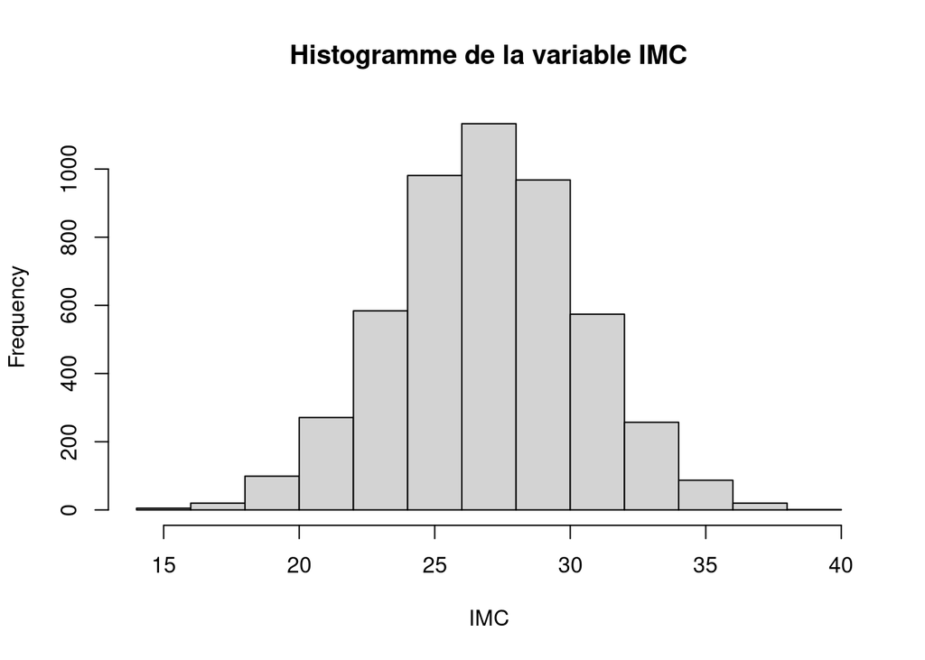

```r
hist(ishare$imc, main = "Histogramme de la variable IMC", xlab = "IMC")
```

24. Représenter le boxplot du score `malbouffe` en fonction du domicile. Ajouter un titre et renommer les axes.

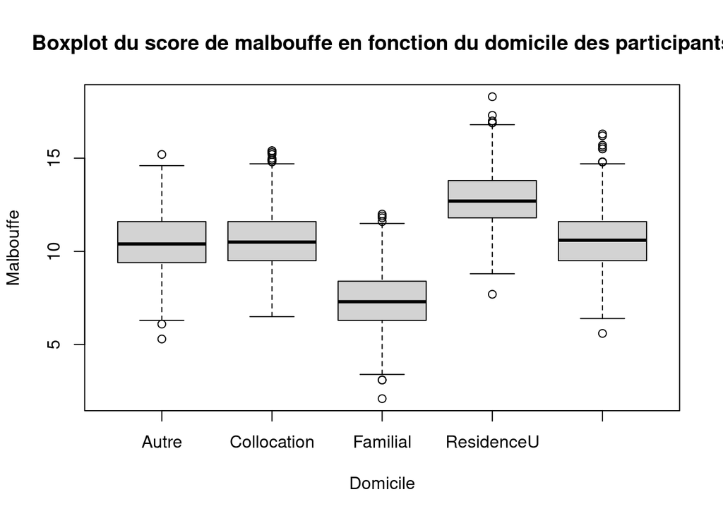

```r
boxplot(ishare$malbouffe~ishare$domicile,
        main = "Boxplot du score de malbouffe en fonction du domicile des participants",
        xlab = 'Domicile',
        ylab = 'Malbouffe')
```

25. Ajouter une variable ratio définie comme étant : $\text{ratio}=\frac{\text{malbouffe}}{\text{fruits}+1}$

```r
ishare$ratio <- (ishare$malbouffe)/(ishare$fruits+1)
```

## Gestion des valeurs manquantes

```r
to_NA_ind <- sample(1:nrow(ishare), 0.2*nrow(ishare))
to_NA_var <- sample(3:ncol(ishare), 0.6*9)
ishare2<- ishare
ishare2[to_NA_ind, c(1,to_NA_var)] <- NA
write.csv(ishare2, file="DonneesIshare_NA.csv", na=".", row.names = F)
```

29. Dans un objet `ishare2`, importer le jeu de données `DonneesIshare_NA.csv`. Comment sont codées les valeurs manquantes dans ce fichier ? S’il y a un problème, refaire l’importation des données en tenant compte de cette remarque.

```r
ishare2 <- read.csv(file = "DonneesIshare_NA.csv", sep = ",", dec = ",", na.strings = ".", stringsAsFactors = TRUE, header = T)
str(ishare2)
```

```
## 'data.frame':    5000 obs. of  11 variables:
##  $ age      : int  18 18 NA 18 18 18 18 NA 18 18 ...
##  $ sexe     : Factor w/ 2 levels "Femme","Homme": 2 1 1 1 1 1 1 2 1 2 ...
##  $ filiere  : Factor w/ 4 levels "Autre","Litteraire",..: 2 4 4 4 2 2 4 2 2 4 ...
##  $ domicile : Factor w/ 5 levels "Autre","Collocation",..: 3 2 NA 2 5 2 5 NA 5 5 ...
##  $ revenus  : Factor w/ 3 levels "Famille","Multi-sources",..: 1 2 2 3 1 3 2 2 3 2 ...
##  $ situation: Factor w/ 3 levels "Confortable",..: 2 2 NA 2 2 2 2 NA 3 2 ...
##  $ etudes   : Factor w/ 2 levels "Au moins 1 etudes sup",..: 2 2 NA 1 2 2 2 NA 2 1 ...
##  $ fruits   : int  4 5 NA 5 3 4 4 NA 4 4 ...
##  $ malbouffe: Factor w/ 138 levels "10","10.1","10.2",..: 133 119 24 125 29 6 1 7 12 138 ...
##  $ exercice : int  0 1 2 3 3 5 6 10 11 12 ...
##  $ imc      : Factor w/ 206 levels "15.1","15.7",..: 78 90 NA 103 116 137 68 NA 187 186 ...
```

30. Calculer l’age moyen des participants de cette étude

```r
mean(ishare2$age, na.rm = TRUE)
```

```
## [1] 22.428
```

```r
# Attention, à cause des valeurs manquantes, il est important de bien utiliser l'argument na.rm=TRUE qui permet d'ignorer les valeurs manquantes pendant le calcul. Sans cette argument, la moyenne ne peut être calculée à cause de NA
```

31. A l’aide de la fonction `na.omit()` supprimer toutes les lignes comportant au moins une valeur manquante. Combien y avait-il d’observations pour lesquelles au moins une valeur était manquante?

```r
ishare_sans_NA <- na.omit(ishare2)
nrow(ishare2) - nrow(ishare_sans_NA)
```

```
## [1] 1000
```

# Données sédentarité

1. Importer DonneesSed dans un data frame intitulé DonneesSed avec la fonction `read.delim()` en concidérant la variable ID comme noms de lignes.

```r
DonneeSed <- read.delim("DonneeSed.txt", row.names = 8)
```

2. Convertir en factor les quatres premières variables et donner un résumé des variables

```r
DonneeSed$UTILISATION_TRAVAIL <- as.factor(DonneeSed$UTILISATION_TRAVAIL)
DonneeSed$DISPOSITIF_OPTHALMOLOGIQUE <- as.factor(DonneeSed$DISPOSITIF_OPTHALMOLOGIQUE)
DonneeSed$MIGRAINE <- as.factor(DonneeSed$MIGRAINE)
DonneeSed$CSP <- as.factor(DonneeSed$CSP)

summary(DonneeSed)
```

```
##  UTILISATION_TRAVAIL DISPOSITIF_OPTHALMOLOGIQUE MIGRAINE         CSP
##  Non: 92             Non:173                    Non:164   cadre    :75
##  Oui:176             Oui: 95                    Oui:104   employé  :61
##                                                           étudiant :70
##                                                           non actif:62
##
##
##       AGE             IMC        HEURE_UTILISATION
##  Min.   :15.00   Min.   :16.01   Min.   : 0.200
##  1st Qu.:21.00   1st Qu.:19.20   1st Qu.: 3.900
##  Median :30.00   Median :21.68   Median : 5.800
##  Mean   :34.98   Mean   :22.23   Mean   : 6.227
##  3rd Qu.:47.00   3rd Qu.:24.32   3rd Qu.: 7.925
##  Max.   :89.00   Max.   :34.76   Max.   :14.900
```

3. Calculer le nombre de personnes qui utilisent 6h ou plus par jour en moyenne les appareils électroniques.

```r
nrow(DonneeSed[DonneeSed$HEURE_UTILISATION>=6,])
```

```
## [1] 130
```

4. Extraire dans un data frame intitulé `DonneeSedAct` les données concernant les personnes actives qui utilisent 6h ou plus par jour en moyenne les appareils électroniques.

```r
levels(DonneeSed$CSP)
```

```
## [1] "cadre"     "employé"   "étudiant"  "non actif"
```

```r
DonneeSedAct <- DonneeSed[DonneeSed$CSP != "non actif" & DonneeSed$HEURE_UTILISATION>=6,]
nrow(DonneeSedAct)
```

```
## [1] 104
```

5. Déterminer la moyenne arrondi au dixième de la durée quotidienne devant les appareils pour les étudiants.

```r
round(mean(DonneeSedAct[DonneeSedAct$CSP == "étudiant","HEURE_UTILISATION" ]), 1)
```

```
## [1] 10.1
```

6. Supprimer la colonne CSP de `DonneeSedAct`

```r
DonneeSedActRmCSP <- subset(DonneeSedAct, select=-c(CSP))
# DonneeSedAct <- DonneeSedAct[,-4]
```

```r
Ecran <- ifelse(DonneeSedAct$HEURE_UTILISATION >= 10, 1, 0)
```

8. Calculer le nombre d’étudiants qui ont la migraine et en déduire la proportion correspondante parmis les étudiants, arrondie au dixième.

```r
num <- nrow(DonneeSedAct[DonneeSedAct$CSP == "étudiant" & DonneeSedAct$MIGRAINE =="Oui",])
denom <- nrow(DonneeSedAct[DonneeSedAct$CSP == "étudiant",])
round(num/denom, 1)
```

```
## [1] 0.4
```